# StatsFitting1_SpeciesLevel

Heywood et al.

This script fits and saves `brms` models predicting size for each species separately.

The core model is: log(Size) ~ YearRescale + Temp + Latitude + Sex. Alternative models that include a ‘spatial random effect’ by fitting a Gaussian Point Processes to capture additional autocorrelation in sizes explainable by the proximity of locations are also tested.

Towards the end of this the improvement in fit that the spatial-autocorrelation term bring is assessed and the fitted coefficients with and without compared .

Models testing fitting distinct responses to the predictors for each sex afre fit in a seperate document (`StatsFitting5`)

`brms` model objects are saved in folders, and summaries of the posteriors are saved as .csvs for further use.

```r
library(tidyverse)
library(brms)
library(posterior)
```

```r
NHM_ForFitting <- read_csv(  '../data/NHM_for_models_monthly.csv')
OUM_ForFitting <- read_csv(  '../data/OUMNH_for_models_monthly.csv')
```

# NHM Fit

## Identify species with enough data

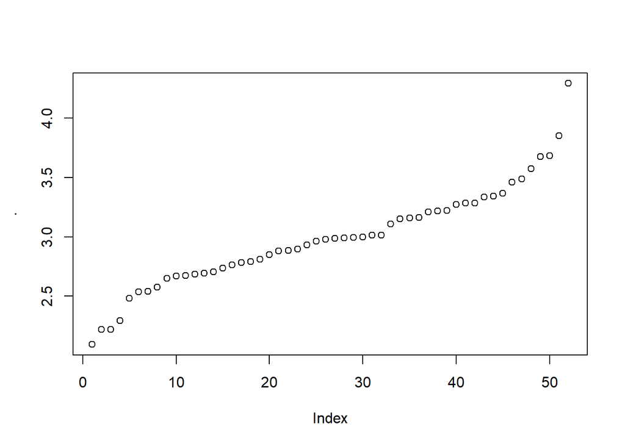

```r
Batches<- count(NHM_ForFitting, Sp)%>% arrange( n)

Batches$n %>% log10 %>% plot; abline(h = 2) # almost perfect log-normal plot
```

```r
sum(Batches$n >100) # 52 species
```

```
## [1] 52
```

```r
Batches %>%
  filter( n >100 ) -> TableOfModels_NHM

median(TableOfModels_NHM$n)
```

```
## [1] 961
```

```r
Set2 = paste0('Sp.', TableOfModels_NHM$Sp)
```

### Spatial aggregation and rescaling of lat longs.

In the NHM dataset, lats and longs are given to implausibly precise 4dp precision (approx 10m), presumably due to some transformation along the way. Because fitting time scales with the cube of the number of distinct locations, it is worth just checking if moderate spatial aggregation of very nearby points impacts the number of distinct collection locations.

```r
# How many unique locations in largest dataset?
full_join(NHM_ForFitting %>%
            distinct( Sp, Latitude, Longitude ) %>%
            count(Sp, sort = TRUE, name = 'Original4dpResCount'),
          NHM_ForFitting %>% ## rounding to nearest km or 10km doesn't affect these counts much.
            mutate( LatitudeRound = round( Latitude, digits = 1), #  Round to nearest ~10km
                    LongitudeRound = round( Longitude, digits = 1)) %>%
            distinct( Sp, LatitudeRound, LongitudeRound ) %>%
            count(Sp, sort = TRUE, name = 'Coarse1dpResCount'))
```

```
## # A tibble: 52 × 3
##    Sp                     Original4dpResCount Coarse1dpResCount
##    <chr>                                <int>             <int>
##  1 Maniola jurtina                        581               358
##  2 Coenonympha pamphilus                  515               329
##  3 Lycaena phlaeas                        431               309
##  4 Pyronia tithonus                       386               275
##  5 Polyommatus icarus                     359               252
##  6 Anthocharis cardamines                 350               251
##  7 Polyommatus coridon                    315               179
##  8 Aphantopus hyperantus                  311               224
##  9 Boloria euphrosyne                     296               207
## 10 Ochlodes sylvanus                      283               206
## # ℹ 42 more rows
```

Since coarsening resolution only makes a moderate reduction in sites, will just fit on original resolution.

Scaling lat and longs across all the species for slightly more consistent values. NB that `gp()` also includes a further (within species) scaling (to make max distance = 1), so the impact is relatively minor.

```r
NHM_ForFitting %>%
  mutate( Scale_Lat = scale( Latitude)[,1],
          Scale_Long= scale(Longitude)[,1]) -> NHM_ForFitting
```

## Fitting Models With Spatial Term

```r
### Define and compile model for first species
CoreModelSP <-   NHM_ForFitting %>%
    filter(Sp == TableOfModels_NHM$Sp[1]) %>%
    brm( log(Right_wing)  ~ YearRescale + Temp  + Latitude + Sex +
           gp(Scale_Lat, Scale_Long,
              cov = "exp_quad", #  Default exponentiated-quadratic kernel
              gr = TRUE),  ## Group observations at the same location
         data = .,
         refresh = 0)

## Refit model to each set of data, saving each time
for( i in 1:nrow( TableOfModels_NHM)){
  print(Set2[i])
  print( Sys.time())
  NHM_ForFitting %>%
    filter(Sp == TableOfModels_NHM$Sp[i]) -> batchDATA
  update( CoreModelSP, newdata = batchDATA, refresh = 0) -> MODEL_FIT
  save(MODEL_FIT, file = paste0('../NHM_modelfitsSpatial/',Set2[i]  ))
}
```

### Checking model fit

```r
MaxRHats_NHM <- map_df(1:nrow( TableOfModels_NHM), function(i){
  load(file = paste0('../NHM_modelfitsSpatial/',Set2[i]  ))
  return( data.frame(Sp =Set2[i],  MaxRhat =  max(rhat(MODEL_FIT)) ) )
})

arrange(MaxRHats_NHM, desc(MaxRhat)) # Glanville Fritillary not converged well
```

```
##                             Sp  MaxRhat
## 1            Sp.Satyrium pruni 1.078576
## 2         Sp.Hipparchia semele 1.055801
## 3        Sp.Boloria euphrosyne 1.034395
## 4         Sp.Gonepteryx rhamni 1.029407
## 5              Sp.Apatura iris 1.021577
## 6           Sp.Speyeria aglaja 1.021023
## 7  Sp.Carterocephalus palaemon 1.019331
## 8     Sp.Coenonympha pamphilus 1.019203
## 9           Sp.Argynnis paphia 1.017933
## 10          Sp.Papilio machaon 1.015820
## 11              Sp.Pieris napi 1.015027
## 12          Sp.Lycaena phlaeas 1.013439
## 13           Sp.Plebejus argus 1.013426
## 14          Sp.Melitaea cinxia 1.012779
```

[output cut: 38 more lines]

### Fixing Glanville Fritillary Convergence issue

From inspection, clearly problem of GPP sd parameter getting stuck far too high on one of the chains. Dropping dodgy first chain (still leaving three that mixed well) is a neater solution than fiddling with priors, or just rerunning the whole analysis and hoping.

```r
 load(file='../NHM_modelfitsSpatial/ Sp.Melitaea cinxia')

 MODEL_FIT
 mcmc_plot(MODEL_FIT, type= 'trace' )

new_fit_wo_stuckchain<- MODEL_FIT

  sim = new_fit_wo_stuckchain$fit@sim
  sim$samples <- sim$samples[-1]
  sim$chains = sim$chains - 1
  sim$warmup2 = sim$warmup2[-1]
  new_fit_wo_stuckchain$fit@sim = sim

  ## Good fit now:
 new_fit_wo_stuckchain
  mcmc_plot(new_fit_wo_stuckchain, type= 'trace' )

  MODEL_FIT<- new_fit_wo_stuckchain
save(MODEL_FIT, file='../NHM_modelfitsSpatial/ Sp.Melitaea cinxia')
```

### Collating model outputs into a df

```r
map_df(1:nrow( TableOfModels_NHM), function(i){
  load(file = paste0('../NHM_modelfitsSpatial/',Set2[i]  ))
  MODEL_FIT %>%
    as_draws_array %>%
    summarise_draws( "mean","median","sd","mad","quantile2",
                    ~quantile2(.x, probs = c(0.167, 0.833))) -> Fit_df
  Fit_df$Sp = TableOfModels_NHM$Sp[i]
  return(Fit_df)
})-> Posterior_Summaries_NHM_Spatial

write_csv(Posterior_Summaries_NHM_Spatial, '../statsresults/NHM_Posterior_Summaries_Spatial.csv')
```

## Repeating Fitting Models without spatial term, for model testing.

```r
### Define and compile model
CoreModel2 <-   NHM_ForFitting %>%
    filter(Sp == TableOfModels_NHM$Sp[1]) %>%
    brm( log(Right_wing)  ~ YearRescale + Temp  + Latitude + Sex,
         data = ., refresh = 0)

## Refit model to each set of data, saving each time
for( i in 1:nrow( TableOfModels_NHM)){
  print(Set2[i])
  NHM_ForFitting %>%
    filter(Sp == TableOfModels_NHM$Sp[i]) -> batchDATA
  update( CoreModel2, newdata = batchDATA, refresh = 0) -> MODEL_FIT
  save(MODEL_FIT, file = paste0('../NHM_modelfitsM1/',Set2[i]  ))
}
```

### Collating model outputs into a df

```r
map_df(1:nrow( TableOfModels_NHM), function(i){
  load(file = paste0('../NHM_modelfitsM1/',Set2[i]  ))
  MODEL_FIT %>%
    as_draws_array %>%
    summarise_draws( "mean","median","sd","mad","quantile2",
                    ~quantile2(.x, probs = c(0.167, 0.833))) -> Fit_df
  Fit_df$Sp = TableOfModels_NHM$Sp[i]
  return(Fit_df)
})-> Posterior_Summaries_NHM2
write_csv(Posterior_Summaries_NHM2, '../statsresults/NHM_Posterior_Summaries_M1.csv')
```

## Correlations between predictors

For each species calculate correlation between predictors

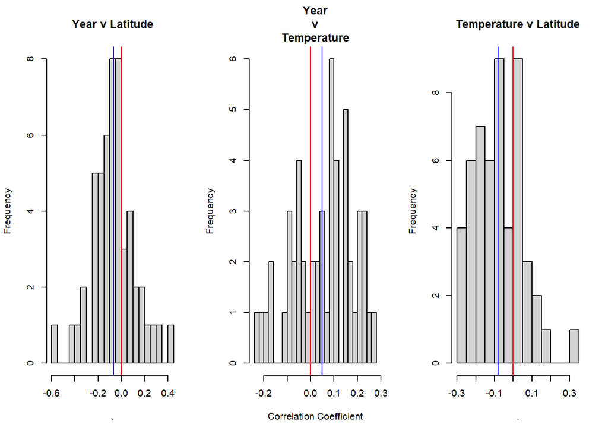

```r
map_df(TableOfModels_NHM$Sp ,function(sp_i){

  NHM_ForFitting%>%
    filter(Sp == sp_i) %>%
    select(Latitude ,Year,Temp) %>%
    cor ->x
  return(data.frame( Species = sp_i,
                       YvL = x[2,1],
                     YvT = x[2,3],
                     LvT = x[1,3]))
})-> SpeciesLvlCorrs

par(mfrow= c(1,3))
SpeciesLvlCorrs$YvL %>% hist(breaks=20, main ='Year v Latitude')
abline(v=0, col = 'red'); abline(v=mean(SpeciesLvlCorrs$YvL), col = 'blue')
SpeciesLvlCorrs$YvT %>% hist(breaks=20, main ='Year\nv\nTemperature', xlab = 'Correlation Coefficient')
abline(v=0, col = 'red'); abline(v=mean(SpeciesLvlCorrs$YvT), col = 'blue')
SpeciesLvlCorrs$LvT %>% hist(breaks=20, main ='Temperature v Latitude')
abline(v=0, col = 'red'); abline(v=mean(SpeciesLvlCorrs$LvT), col = 'blue')
```

```r
png(file ='../figs/SI_corr_inTempLatYear.png',
    units ='in', width = 5, height = 3, res = 400)
par(mfrow= c(1,3))
SpeciesLvlCorrs$YvL %>% hist(breaks=20, main ='Year\nv\nLatitude')
abline(v=0, col = 'red'); abline(v=mean(SpeciesLvlCorrs$YvL), col = 'blue')
SpeciesLvlCorrs$YvT %>% hist(breaks=20, main ='Year\nv\nTemperature', xlab = 'Correlation Coefficient')
abline(v=0, col = 'red'); abline(v=mean(SpeciesLvlCorrs$YvT), col = 'blue')
SpeciesLvlCorrs$LvT %>% hist(breaks=20, main ='Temperature\nv\nLatitude')
abline(v=0, col = 'red'); abline(v=mean(SpeciesLvlCorrs$LvT), col = 'blue')
dev.off()
```

# OUMNH Model fitting

## Identify species with enough data

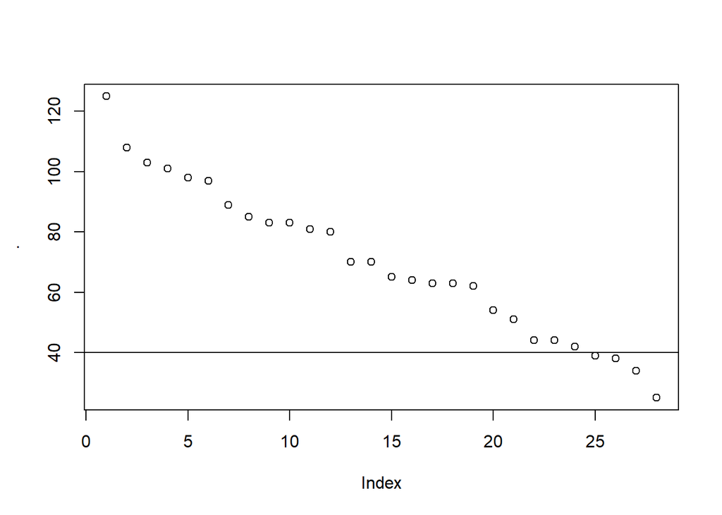

```r
## Cycle through each species to fit models
Batches<- count(OUM_ForFitting,Sp)%>%
  arrange( desc(n))
Batches$n  %>% plot; abline(h = 40) # almost perfect log-normal plot
```

```r
Batches %>%
  filter( n >1) -> TableOfModels_OUMNH ## No longer include a threshold

TableOfModels_OUMNH$n %>% median
```

```
## [1] 67.5
```

```r
Set2 = paste0('Sp.', TableOfModels_OUMNH$Sp)
```

## Model with Spatial Autocorrelation Term

NB some species are not differentiated at all by sex, so for those species need to fit a model without a sex-intercept.

```r
OUM_ForFitting %>%
  mutate( Scale_Lat = scale( Latitude)[,1],
          Scale_Long= scale(Longitude)[,1]) -> OUM_ForFitting

CoreModel_OU_splitSex <-   OUM_ForFitting %>%
  filter(Sp == TableOfModels_OUMNH$Sp[4]) %>%
  brm( log(Wing_Length)   ~ YearRescale + Temp  + Latitude + Sex +
           gp(Scale_Lat ,  Scale_Long ,
              cov = "exp_quad", #  Default exponentiated-quadratic kernel
              gr = TRUE),  ## Group observations at the same location
       data = ., refresh = 0)

CoreModel_OU_jointSex <-   OUM_ForFitting %>%
  filter(Sp == TableOfModels_OUMNH$Sp[2]) %>%
  brm( log(Wing_Length)   ~ YearRescale + Temp  + Latitude +
           gp(Scale_Lat , Scale_Long ,
              cov = "exp_quad", #  Default exponentiated-quadratic kernel
              gr = TRUE),  ## Group observations at the same location,
       data = ., refresh = 0)

undetermined_sp<- distinct(OUM_ForFitting, Sp, Sex) %>% filter( Sex == 'undetermined') %>% pluck('Sp')

## Refit model to each set of data, saving each time
for( i in 1:nrow( TableOfModels_OUMNH)){
  print(Set2[i])
  if(TableOfModels_OUMNH$Sp[i] %in% undetermined_sp ){
    OUM_ForFitting %>%
      filter(Sp == TableOfModels_OUMNH$Sp[i]) -> batchDATA
    update( CoreModel_OU_jointSex, newdata = batchDATA, refresh = 0,
            iter = 10000 ) -> MODEL_FIT

  }else{
    OUM_ForFitting %>%
      filter(Sp == TableOfModels_OUMNH$Sp[i]) -> batchDATA
    update( CoreModel_OU_splitSex, newdata = batchDATA, refresh = 0,
            iter = 10000 ) -> MODEL_FIT
  }
  save(MODEL_FIT, file = paste0('../OUM_modelfitsSpatial/',Set2[i]  ))
}
```

### Checking model fit

```r
MaxRHats <- map_df(1:nrow( TableOfModels_OUMNH), function(i){
  load(file = paste0('../OUM_modelfitsSpatial/',Set2[i]  ))
  return( data.frame(Sp =Set2[i],  MaxRhat =  max(rhat(MODEL_FIT)) ) )
})

TableOfModels_OUMNH %>%
  select(n) %>%
  add_column('Sp' = Set2) %>%
  left_join(MaxRHats ) %>%
arrange(desc(MaxRhat)) -> N_v_MaxRhat
N_v_MaxRhat
```

```
## # A tibble: 28 × 3
##        n Sp                       MaxRhat
##    <int> <chr>                      <dbl>
##  1    25 Sp.Celastrina argiolus      1.26
##  2    98 Sp.Thymelicus sylvestris    1.09
##  3    63 Sp.Polyommatus icarus       1.07
##  4    44 Sp.Coenonympha tullia       1.04
##  5    38 Sp.Pararge aegeria          1.02
##  6    62 Sp.Lasiommata megera        1.02
##  7    70 Sp.Maniola jurtina          1.02
##  8    80 Sp.Aglais io                1.01
##  9    34 Sp.Aglais urticae           1.01
## 10    54 Sp.Papilio machaon          1.01
## # ℹ 18 more rows
```

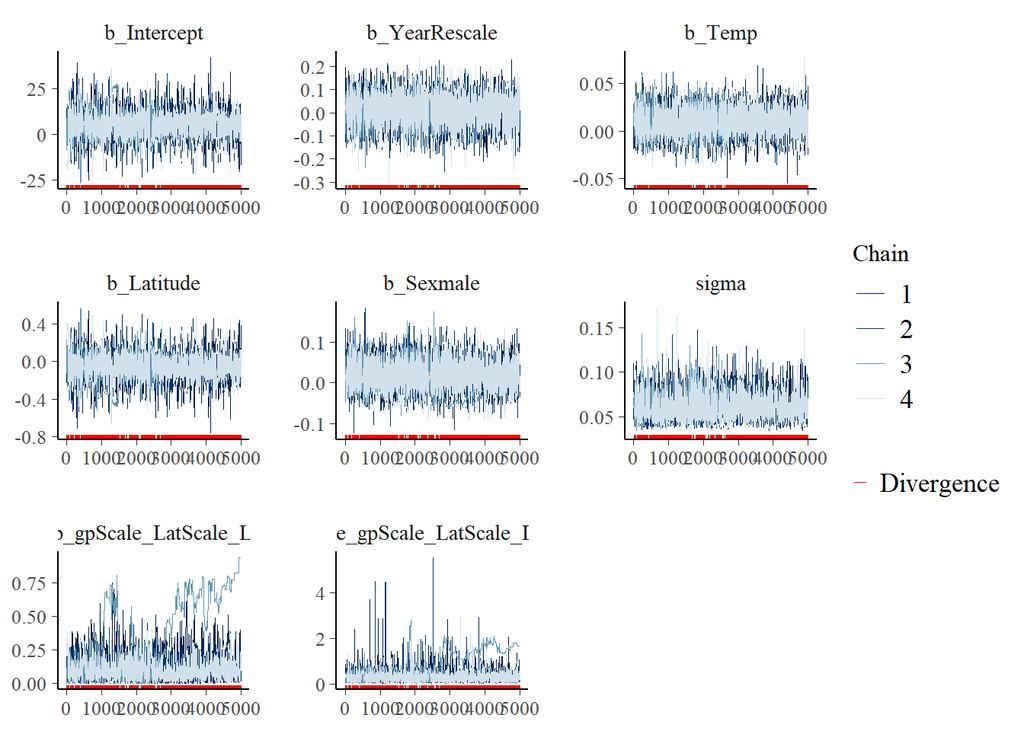

```r
## inspecting worse case (only 25 specimens...)
load('../OUM_modelfitsSpatial/Sp.Celastrina argiolus')
mcmc_plot(MODEL_FIT, type= 'trace' )  ## problem of GPP sd getting stuck far too high. Will just leave as end up not finding spatial term helpful and just using the direct regression.
```

### Collating model outputs into a df

```r
map_df(1:nrow( TableOfModels_OUMNH), function(i){
  load(file = paste0('../OUM_modelfitsM1/',Set2[i]  ))
  MODEL_FIT %>%
    as_draws_array %>%
    summarise_draws("mean","median","sd","mad","quantile2",
                    ~quantile2(.x, probs = c(0.167, 0.833))) -> Fit_df
  Fit_df$Sp = TableOfModels_OUMNH$Sp[i]
  return(Fit_df)
})-> Posterior_Summaries_OUM_Spatial

write_csv(Posterior_Summaries_OUM_Spatial, '../statsresults/OUM_Posterior_Summaries_Spatial.csv')
```

## Without Spatial Autcorrelation

```r
CoreModel_OU_splitSex <-   OUM_ForFitting %>%
  filter(Sp == TableOfModels_OUMNH$Sp[4]) %>%
  brm( log(Wing_Length)   ~ YearRescale + Temp  + Latitude + Sex,
       data = ., refresh = 0)

CoreModel_OU_jointSex <-   OUM_ForFitting %>%
  filter(Sp == TableOfModels_OUMNH$Sp[2]) %>%
  brm( log(Wing_Length)   ~ YearRescale + Temp  + Latitude ,
       data = ., refresh = 0)

undetermined_sp<- distinct(OUM_ForFitting, Sp, Sex) %>% filter( Sex == 'undetermined') %>% pluck('Sp')

## Refit model to each set of data, saving each time
for( i in 1:nrow( TableOfModels_OUMNH)){
  print(Set2[i])
  if(TableOfModels_OUMNH$Sp[i] %in% undetermined_sp ){
    OUM_ForFitting %>%
      filter(Sp == TableOfModels_OUMNH$Sp[i]) -> batchDATA
    update( CoreModel_OU_jointSex, newdata = batchDATA, refresh = 0) -> MODEL_FIT

  }else{
    OUM_ForFitting %>%
      filter(Sp == TableOfModels_OUMNH$Sp[i]) -> batchDATA
    update( CoreModel_OU_splitSex, newdata = batchDATA, refresh = 0) -> MODEL_FIT
  }
  save(MODEL_FIT, file = paste0('../OUM_modelfitsM1/',Set2[i]  ))
}
```

### Collating model outputs into a df

```r
map_df(1:nrow( TableOfModels_OUMNH), function(i){
  load(file = paste0('../OUM_modelfitsM1/',Set2[i]  ))
  MODEL_FIT %>%
    as_draws_array %>%
    summarise_draws("mean","median","sd","mad","quantile2",
                    ~quantile2(.x, probs = c(0.167, 0.833))) -> Fit_df
  Fit_df$Sp = TableOfModels_OUMNH$Sp[i]
  return(Fit_df)
})-> Posterior_Summaries_OUM2

write_csv(Posterior_Summaries_OUM2, '../statsresults/OUM_Posterior_Summaries_M1.csv')
```

# Testing Influence of Spatial Autocorrelation term.

## NHM Model Compare

Comparing models with ELPD. Need to add criterion to the model fits, so takes about 10 minutes to run. (.csv outputs saved for reuse. )

```r
count(NHM_ForFitting,Sp) %>%
  filter( n >100 ) -> TableOfModels_NHM
Set2 = paste0('Sp.', TableOfModels_NHM$Sp)

map_df(1:52, function(i){

  load(file = paste0('../NHM_modelfitsSpatial/',Set2[i]  ))
  SPATIAL_MF <- MODEL_FIT

  load(file = paste0('../NHM_modelfitsM1/',Set2[i]  ))
  ORIG_MF <- MODEL_FIT

  SPATIAL_MF<-  add_criterion(SPATIAL_MF, "loo")
  ORIG_MF<-  add_criterion(ORIG_MF,    "loo")

  XX<- rownames_to_column(as.data.frame(loo_compare(SPATIAL_MF, ORIG_MF)))
  XX$Sp = TableOfModels_NHM$Sp[i]
  print(TableOfModels_NHM$Sp[i])
  return(XX)
})-> LOO_CompareDF
write_csv(LOO_CompareDF, '../statsresults/SpatialLOOCompares.csv')
```

```r
LOO_CompareDF<-read_csv('../statsresults/SpatialLOOCompares.csv')
LOO_CompareDF%>%
  select(rowname,elpd_diff,se_diff, Sp) %>%
  filter( elpd_diff <0) %>%
  mutate(ConfidentDiff = elpd_diff < -4 & (-elpd_diff > (2*se_diff))) %>%
  arrange(ConfidentDiff) %>%
  rename('Worse Model' = rowname ) %>%
  knitr::kable()
```

| Worse Model | elpd_diff | se_diff | Sp | ConfidentDiff |
| --- | --- | --- | --- | --- |
| ORIG_MF | -4.6043708 | 3.8840633 | Celastrina argiolus | FALSE |
| SPATIAL_MF | -0.6716413 | 0.5682672 | Gonepteryx rhamni | FALSE |
| ORIG_MF | -7.1654502 | 3.7065320 | Limenitis camilla | FALSE |
| ORIG_MF | -0.1852274 | 1.2348131 | Melitaea cinxia | FALSE |
| SPATIAL_MF | -0.4631423 | 0.4875942 | Nymphalis polychloros | FALSE |
| ORIG_MF | -1.2531487 | 1.8506527 | Papilio machaon | FALSE |
| ORIG_MF | -2.1829590 | 2.2311280 | Pieris napi | FALSE |
| ORIG_MF | -0.1199042 | 1.5737892 | Pieris rapae | FALSE |
| SPATIAL_MF | -0.6592422 | 0.6145700 | Polygonia c-album | FALSE |
| ORIG_MF | -10.6296911 | 5.8692133 | Speyeria aglaja | FALSE |
| ORIG_MF | -2.1133271 | 2.1979708 | Thecla betulae | FALSE |
| SPATIAL_MF | -0.8049334 | 0.6571892 | Thymelicus acteon | FALSE |
| ORIG_MF | -31.2873379 | 8.1733566 | Aglais io | TRUE |
| ORIG_MF | -38.8189224 | 8.6993452 | Aglais urticae | TRUE |
| ORIG_MF | -36.6587401 | 9.2995310 | Anthocharis cardamines | TRUE |
| ORIG_MF | -9.2093594 | 4.1520416 | Apatura iris | TRUE |
| ORIG_MF | -40.9993280 | 9.4789525 | Aphantopus hyperantus | TRUE |
| ORIG_MF | -95.4714843 | 13.7390637 | Argynnis paphia | TRUE |
| ORIG_MF | -22.4234563 | 6.6777697 | Aricia agestis | TRUE |
| ORIG_MF | -35.0114990 | 8.3785992 | Boloria euphrosyne | TRUE |
| ORIG_MF | -125.4180777 | 16.1246433 | Boloria selene | TRUE |
| ORIG_MF | -36.5828386 | 9.4230902 | Callophrys rubi | TRUE |
| ORIG_MF | -17.1143558 | 5.6227887 | Carterocephalus palaemon | TRUE |
| ORIG_MF | -129.2050774 | 17.1803523 | Coenonympha pamphilus | TRUE |
| ORIG_MF | -31.8383339 | 8.0752413 | Coenonympha tullia | TRUE |
| ORIG_MF | -21.6244667 | 6.5591672 | Cupido minimus | TRUE |
| ORIG_MF | -48.5517990 | 9.8553843 | Erynnis tages | TRUE |
| ORIG_MF | -77.9260492 | 11.9870572 | Euphydryas aurinia | TRUE |
| ORIG_MF | -44.5888699 | 9.0941666 | Fabriciana adippe | TRUE |
| ORIG_MF | -19.7569502 | 6.5529420 | Favonius quercus | TRUE |
| ORIG_MF | -48.4291158 | 10.3671894 | Hamearis lucina | TRUE |
| ORIG_MF | -52.1812058 | 9.5641523 | Hesperia comma | TRUE |
| ORIG_MF | -183.8038401 | 18.3599411 | Hipparchia semele | TRUE |
| ORIG_MF | -25.8249151 | 7.7278520 | Lasiommata megera | TRUE |
| ORIG_MF | -29.0312592 | 7.4595322 | Leptidea sinapis | TRUE |
| ORIG_MF | -22.3093849 | 7.2458315 | Lycaena phlaeas | TRUE |
| ORIG_MF | -100.9675037 | 13.8532826 | Maniola jurtina | TRUE |
| ORIG_MF | -29.2556557 | 7.6522849 | Melanargia galathea | TRUE |
| ORIG_MF | -35.3887387 | 8.6819060 | Melitaea athalia | TRUE |
| ORIG_MF | -39.1653495 | 8.6784447 | Ochlodes sylvanus | TRUE |
| ORIG_MF | -37.3622673 | 7.7159610 | Pararge aegeria | TRUE |
| ORIG_MF | -13.9692296 | 5.8115218 | Pieris brassicae | TRUE |
| ORIG_MF | -1542.8369371 | 55.5846533 | Plebejus argus | TRUE |
| ORIG_MF | -87.8847581 | 13.2742246 | Polyommatus bellargus | TRUE |
| ORIG_MF | -491.4968554 | 36.8628308 | Polyommatus coridon | TRUE |
| ORIG_MF | -77.4797093 | 12.3148436 | Polyommatus icarus | TRUE |
| ORIG_MF | -10.2266492 | 4.8584829 | Pyrgus malvae | TRUE |
| ORIG_MF | -35.4283237 | 8.4731564 | Pyronia tithonus | TRUE |
| ORIG_MF | -7.9367349 | 3.8457592 | Satyrium pruni | TRUE |
| ORIG_MF | -37.9533061 | 8.4060808 | Satyrium w-album | TRUE |
| ORIG_MF | -35.4964497 | 7.7432094 | Thymelicus lineola | TRUE |
| ORIG_MF | -14.3036240 | 5.7000192 | Thymelicus sylvestris | TRUE |

### Comparing Coefficients

```r
Posterior_Summaries_NHM_SPATIAL<-read_csv('../statsresults/NHM_Posterior_Summaries_Spatial.csv')
Posterior_Summaries_NHM_SPATIAL$Fit <- 'Spatial'

Posterior_Summaries_NHM_ORIG <- read_csv('../statsresults/NHM_Posterior_Summaries_M1.csv')
```

```
## `height` was translated to `width`.
## `height` was translated to `width`.
```

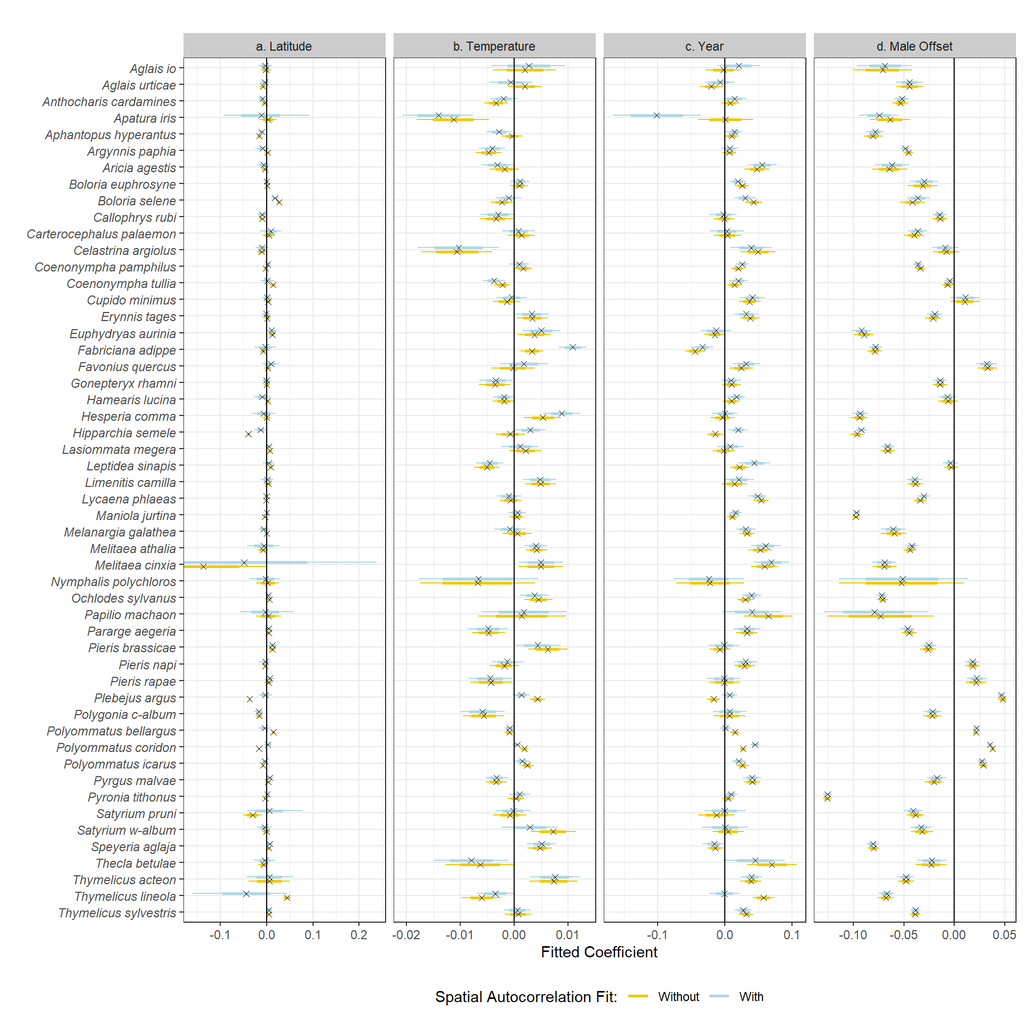

```r
Posterior_Summaries_NHM_ORIG$Fit <- 'Orig_NoSpatial'

Both_Posteriors <- bind_rows(Posterior_Summaries_NHM_SPATIAL, Posterior_Summaries_NHM_ORIG)

Both_Posteriors %>%
  mutate( q5 = if_else(variable== 'b_Latitude' & Sp =='Melitaea cinxia',
                       -Inf, q5)) %>%
  mutate( q16.7 = if_else(variable== 'b_Latitude' & Sp =='Melitaea cinxia',
                          -Inf, q16.7)) %>%
  filter( variable %in% c( 'b_Temp',
                           'b_YearRescale',
                           'b_Sexmale',
                           'b_Latitude') )%>%
  mutate(Response = case_match(variable,
                               'b_Temp'~ 'b. Temperature',
                               'b_YearRescale'~'c. Year',
                               'b_Sexmale'~'d. Male Offset',
                               'b_Latitude'~'a. Latitude') ) -> DataForMainNHMPlot
DataForMainNHMPlot%>%
  ggplot( aes( y =  fct_rev(Sp),
               x = mean, col = Fit, group= Fit))+
  geom_errorbarh(aes( xmin = q5, xmax = q95),
                 linewidth = 0.5, height = 0,
                 position =  position_dodge(width =0.5))+
  geom_errorbarh(aes(xmin = q16.7, xmax =  q83.3),
                 linewidth = 1, height = 0,
                 position =  position_dodge(width =0.5))+
  geom_point(shape = 4,
                 position =  position_dodge(width =0.5), col = 'black')+
  geom_vline(xintercept = 0)+
  facet_grid(~Response, scales = 'free', space = "free_y")+
    scale_color_manual(labels = c('Without'  , 'With'),
                       values= c('gold2', 'lightblue'), name = 'Spatial Autocorrelation Fit:')+
  ggtitle('')+
  theme_bw()+
  ylab('')+
  xlab('Fitted Coefficient')+
  theme(strip.text.y.right = element_text(angle = 0),
        legend.position = 'bottom',
        axis.text.y = element_text(face =  "italic"),
        strip.background = element_rect(fill = 'grey80', colour = NA))
```

```r
 ggsave('../figs/Compare_Spatial_NonSpatial.pdf', height = 10, width = 10)
```

```
## `height` was translated to `width`.
## `height` was translated to `width`.
```

```r
 ggsave('../figs/Compare_Spatial_NonSpatial.png', height = 10, width = 10)
```

```
## `height` was translated to `width`.
## `height` was translated to `width`.
```

## OUM Spatial Autocorrelation Model comparisons.

NB much smaller datasets, but still takes a few minutes to calculate the LOO critera. Quite a lot of the species have 1-2 very outlying observations that trigger concerns based on expectation of Pareto distributions.

```r
count(OUM_ForFitting,Sp)%>%
  filter( n >1) -> TableOfModels_OUMNH ## No threshold
Set2 = paste0('Sp.', TableOfModels_OUMNH$Sp)

map_df(1:28, function(i){

  load(file = paste0('../OUM_modelfitsSpatial/',Set2[i]  ))
  SPATIAL_MF <- MODEL_FIT

  load(file = paste0('../OUM_modelfitsM1/',Set2[i]  ))
  ORIG_MF <- MODEL_FIT

  SPATIAL_MF<-  add_criterion(SPATIAL_MF, "loo")
  ORIG_MF<-  add_criterion(ORIG_MF,    "loo")

  XX<- rownames_to_column(as.data.frame(loo_compare(SPATIAL_MF, ORIG_MF)))
  XX$Sp = TableOfModels_OUMNH$Sp[i]
  print(TableOfModels_OUMNH$Sp[i])
  return(XX)
})-> LOO_CompareDF_OUM
write_csv(LOO_CompareDF_OUM, '../statsresults/SpatialLOOCompares_OUM.csv')
```

Only one of the species could demonstrate a confident case to include the random effect.

Also note that a few of the species the convergence was a bit ropey with the spatial autocorrelation term.

```r
LOO_CompareDF_OUM<-read_csv('../statsresults/SpatialLOOCompares_OUM.csv')
LOO_CompareDF_OUM%>%
  select(rowname,elpd_diff,se_diff, Sp) %>%
  filter( elpd_diff <0) %>%
  mutate(ConfidentDiff = elpd_diff < -4 & (-elpd_diff > (2*se_diff))) %>%
  arrange(ConfidentDiff) %>%
  rename('Worse Model' = rowname ) %>%
  knitr::kable()
```

| Worse Model | elpd_diff | se_diff | Sp | ConfidentDiff |
| --- | --- | --- | --- | --- |
| SPATIAL_MF | -0.8507628 | 0.4227062 | Aglais io | FALSE |
| SPATIAL_MF | -0.3085608 | 0.6532399 | Aglais urticae | FALSE |
| SPATIAL_MF | -1.2172963 | 0.2938840 | Anthocharis cardamines | FALSE |
| ORIG_MF | -2.2649747 | 3.0127247 | Argynnis paphia | FALSE |
| SPATIAL_MF | -0.0407218 | 0.9172370 | Aricia agestis | FALSE |
| ORIG_MF | -1.0335030 | 2.1489753 | Celastrina argiolus | FALSE |
| ORIG_MF | -6.5077298 | 4.0435458 | Coenonympha tullia | FALSE |
| ORIG_MF | -7.1578212 | 4.0442693 | Cupido minimus | FALSE |
| SPATIAL_MF | -0.4299578 | 1.0040856 | Erynnis tages | FALSE |
| ORIG_MF | -0.9153460 | 1.8275401 | Favonius quercus | FALSE |
| SPATIAL_MF | -0.4150446 | 0.9108794 | Gonepteryx rhamni | FALSE |
| ORIG_MF | -0.3507674 | 1.5362124 | Hesperia comma | FALSE |
| SPATIAL_MF | -0.5550980 | 0.6084087 | Lasiommata megera | FALSE |
| ORIG_MF | -0.2829303 | 1.2431286 | Leptidea sinapis | FALSE |
| SPATIAL_MF | -0.7077980 | 1.1219063 | Limenitis camilla | FALSE |
| SPATIAL_MF | -1.1309728 | 2.0763320 | Lycaena phlaeas | FALSE |
| ORIG_MF | -3.0177494 | 3.0413346 | Maniola jurtina | FALSE |
| SPATIAL_MF | -1.1343347 | 0.8771249 | Melanargia galathea | FALSE |
| SPATIAL_MF | -0.4387870 | 0.8093546 | Papilio machaon | FALSE |
| SPATIAL_MF | -0.0176824 | 1.2752124 | Pararge aegeria | FALSE |
| SPATIAL_MF | -0.4313342 | 1.1520901 | Polygonia c-album | FALSE |
| SPATIAL_MF | -0.6512806 | 0.8277933 | Polyommatus bellargus | FALSE |
| SPATIAL_MF | -0.8150929 | 0.4457834 | Polyommatus icarus | FALSE |
| SPATIAL_MF | -0.9398094 | 0.2738019 | Pyrgus malvae | FALSE |
| ORIG_MF | -5.4679073 | 36.0067038 | Pyronia tithonus | FALSE |
| ORIG_MF | -4.2517246 | 2.6585316 | Speyeria aglaja | FALSE |
| SPATIAL_MF | -0.8023135 | 0.5437387 | Thymelicus sylvestris | FALSE |
| ORIG_MF | -7.3752639 | 3.1241931 | Pieris brassicae | TRUE |